# Reproducible Research: Peer Assessment 1

## Loading and preprocessing the data

The following libraries were loaded to facilitate the analysis:

```r
library(knitr)
library(ggplot2)
library(magrittr)
library(lubridate)
library(dplyr)
```

Data was downloaded directly via the coursera website, unzipped, read into R as a dataframe. The “date” column was converted from ‘character’ to POSIXt date class, and the steps column was conveted from ‘integer’ to ‘numeric’.

```r
temp <- tempfile()
url <- "https://d396qusza40orc.cloudfront.net/repdata%2Fdata%2Factivity.zip"
download.file(url, temp, method = "curl")
activity <- read.csv(unz(temp, "activity.csv"))
unlink(temp)

activity$date <- ymd(activity$date)
activity$steps <- as.numeric(activity$steps)
```

## What is mean total number of steps taken per day?

Using dplyr, a dataframe “steps_per_day” was generated that sums total steps across all time intervals for a given day.

```r
steps_per_day <-
    activity %>%
        group_by(date) %>%
        summarise(total = sum(steps, na.rm = TRUE))
```

The “steps_per_day” dataframe was used to produce the following histogram:

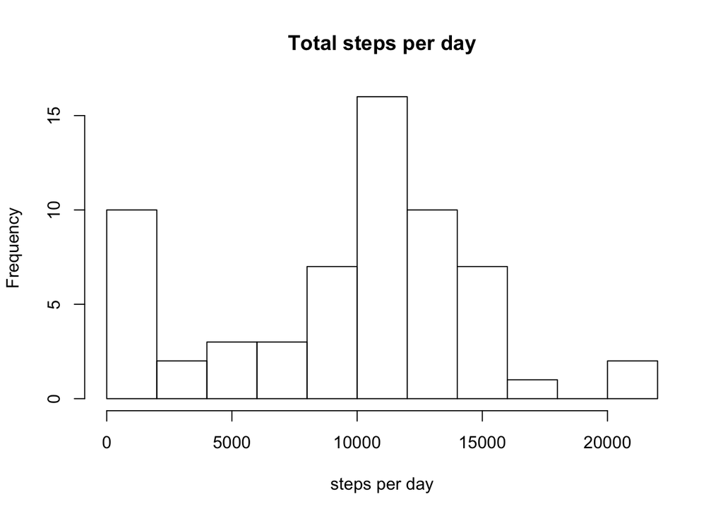

```r
hist(steps_per_day$total, breaks = 11, main = "Total steps per day",
     xlab = "steps per day")
```

```r
mean_per_day <- mean(steps_per_day$total)
median_per_day <- median(steps_per_day$total)
```

From this data, the mean number of steps per day is 9354.2295, and the median steps per day is 1.0395 × 10<sup>4</sup>.

## What is the average daily activity pattern?

Using dplyr, the dataframe “steps_per_interval” was generated that determines the mean number of steps for each time interval across all days in the dataset.

```r
steps_per_interval <-
    activity %>%
    group_by(interval) %>%
    summarise(total = mean(steps, na.rm = TRUE))
```

A timeseries plot of the “steps_per_interval” data was produced using ggplot2.

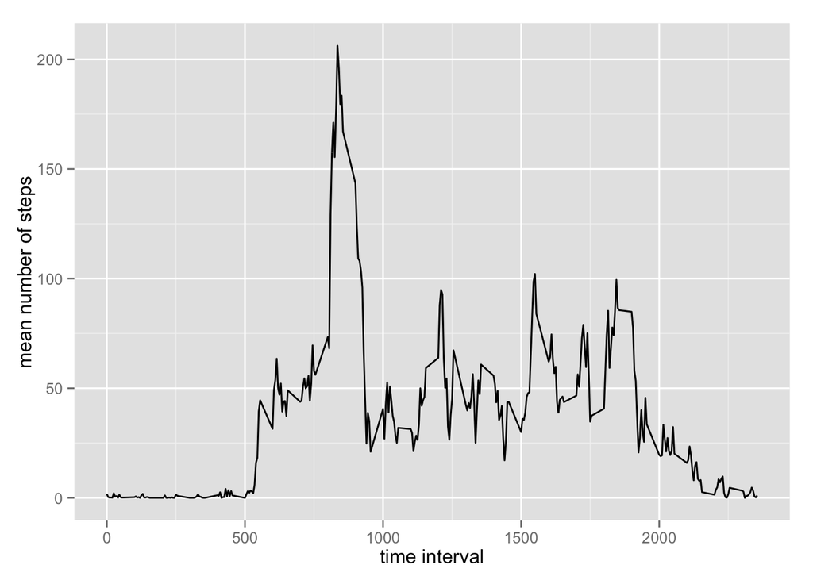

```r
ggplot(steps_per_interval, aes(interval, total)) + geom_line() +
    xlab("time interval") + ylab("mean number of steps")
```

To determine the interval with the most steps on average, the “steps_per_interval” was arranged in descending order by mean number of steps, and printed using the ‘head’ function to return the intervals with the five highest mean number of steps.

```r
head(arrange(steps_per_interval, desc(total)), 5)
```

```
## Source: local data frame [5 x 2]
##
##   interval total
## 1      835 206.2
## 2      840 195.9
## 3      850 183.4
## 4      845 179.6
## 5      830 177.3
```

From this data, it is clear that interval 835 has the highest mean number of steps with an average of 206.2 steps across all days.

## Imputing missing values

The number of “NA” values in the “steps” column of the “activity” dataframe were calculated using the following:

```r
missing <- is.na(activity$steps) %>% which %>% length
```

The number of missing values is 2304.

I have decided to replace these missing values with the median number of steps per interval from the “steps_per_interval” dataframe.

```r
replacement <- median(steps_per_interval$total)
```

The value being used for the imputation is 34.1132 steps.

Using dplyr, the “activity” data frame was regenerated with all NA values substituted with the “replacement” value of 34.1132 steps.

```r
imputed_activity <-
    activity %>%
        group_by(date, interval) %>%
        mutate(steps = ifelse(is.na(steps),
                replacement,
                steps)
               ) %>%
        as.data.frame
```

dplyr was then used again to generate the “imp_steps_per_day” dataframe which sums the total number of steps for each interval across each day. This dataframe can then be used to determine the mean and median of the imputed dataset.

```r
imp_steps_per_day <-
        imputed_activity %>%
            group_by(date) %>%
            summarise(total = sum(steps, na.rm = TRUE))
```

```r
imp_mean_per_day <- mean(imp_steps_per_day$total)
imp_median_per_day <- median(imp_steps_per_day$total)
```

The mean from the imputed data is 1.0643 × 10<sup>4</sup> and the median is 1.0395 × 10<sup>4</sup>. The median is identical to that of the non-imputed dataset. The mean of the imputed dataset, however, has increased its value by ~14%.

A histogram of the data largely maintains the shape of the distribution. However, it is clear that the large number of “zeroes” in the original dataset have now been replaced with 34.1132 in the imputed dataset.

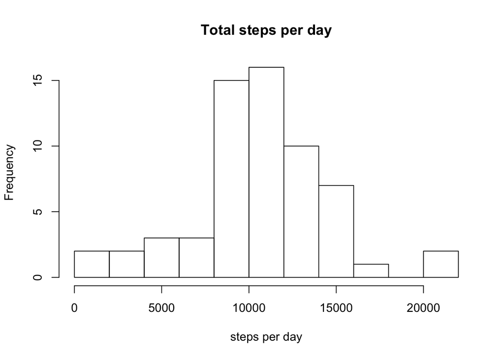

```r
hist(imp_steps_per_day$total, breaks = 11, main = "Total steps per day",
     xlab = "steps per day")
```

## Are there differences in activity patterns between weekdays and weekends?

Using dplyr, a new dataframe, ‘wkds’, was generated that is identical to the imputed data “imputed_activity”, except it contains an additional factor column listing each date as either a “Weekday”" or “Weekend”. This was done by first generating the “day” column using the “weekdays()” function, followed by grep-substitution of all day names to the appropriate “Weekend” or “Weekday” substitution.

```r
wkds <-
    imputed_activity %>%
        group_by(date, interval) %>%
        summarise(day = weekdays(date), steps) %>%
        as.data.frame

wkds <- sapply(wkds, gsub, pattern = '(Saturday)|(Sunday)',
               replacement = 'Weekend') %>%
                as.data.frame

wkds <- sapply(wkds, gsub, pattern = "^.*day$",
                replacement = 'Weekday') %>%
                as.data.frame
wkds$day <- wkds$day %>% as.factor
wkds$steps <- as.numeric(wkds$steps)
```

```r
steps_per_day_interval <-
    wkds %>%
    group_by(interval, day) %>%
    summarise(total = mean(steps, na.rm = TRUE))

steps_per_day_interval$interval <- steps_per_day_interval$interval %>% as.numeric
```

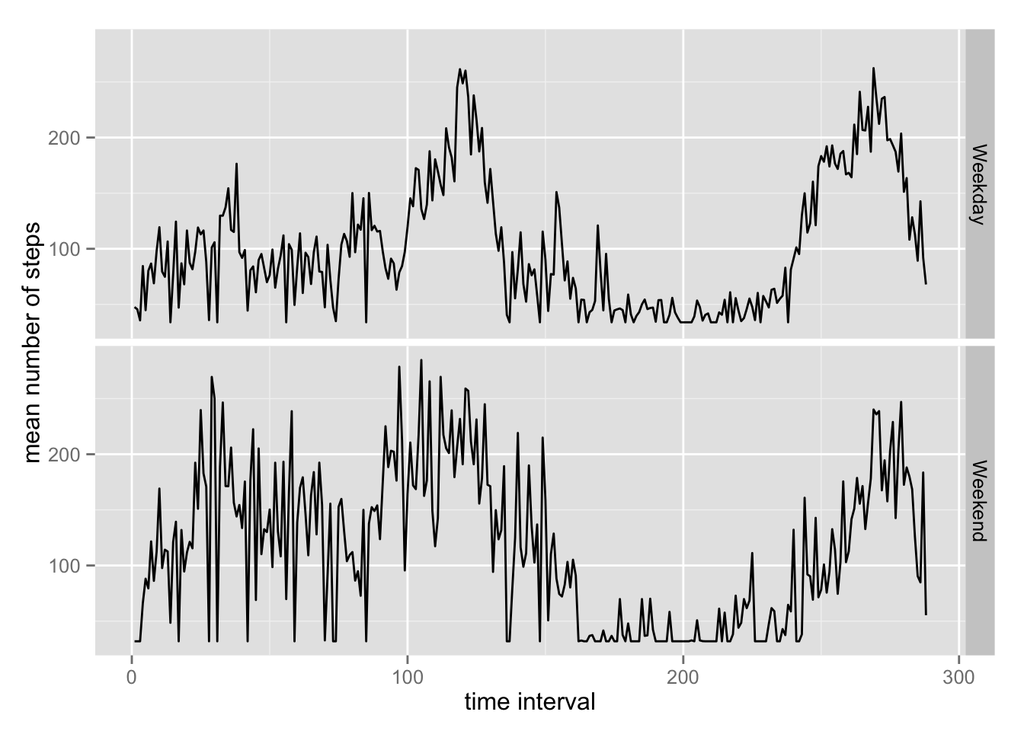

```r
ggplot(steps_per_day_interval, aes(interval, total)) + geom_line() +
           facet_grid(day ~ .) + xlab("time interval") + ylab("mean number of steps")
```